# Homework 5

Tony Daza

2022-10-27

# Question 1

The YAML: Change the highlight to Espresso

Homework 5, which is all about R markdown.

# Question 2

The set up: You can’t see it but it is there

# Question 3

Importing Data and Creating graphs: Data from Ecls K Sample

Looking at t2m scale vs t1m scale by race and school type t1mscale = T1 Math IRT scale score t2mscale = T2 Math IRT scale score

```
##                                    ethnic
## 1                     WHITE, NON-HISPANIC
## 2 BLACK OR AFRICAN AMERICAN, NON-HISPANIC
## 3                HISPANIC, RACE SPECIFIED
## 4            HISPANIC, RACE NOT SPECIFIED
## 5                                   ASIAN
## 6 NATIVE HAWAIIAN, OTHER PACIFIC ISLANDER
## 7        AMERICAN INDIAN OR ALASKA NATIVE
## 8        MORE THAN ONE RACE, NON HISPANIC
```

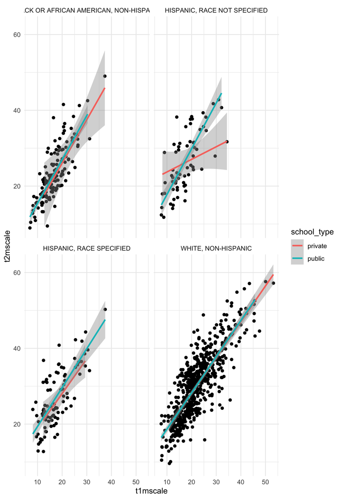

As you can see, there are more white, non hispanic students than minority students in this sample and there scores tended to be higher than the Hispanic and Black students.

# Question 4

# Question 5

Mean and Standard Deviation Continued:

T1 Mean/Std and T2 Mean/Std

T1 Mean score = 20.5059299

T1 standard deviation score = 7.3724682

T2 standard deviation score = 8.7809823

Difference in scores = 8.0607073

*i.e. the average gain*

# Question 6

Loading Data Tutorial:

So let’s say you are *new* to **R studio** and need to **load** in some data. *Follow along* to find out how to load in your data.

**Step 1** Save data to your drive or computer *Remember where you saved your data*

**Step 2** Load **rio** to your console

*You can load a package using the library( ) function

# You will have to install rio first if it is not yet added

**Step 3** Use the **import ()** function in rio to read in your data

*when reading in the data you will need to copy the file pathway exactly and place it in quotes

**Step 4** Save in your data using a nickname

You will need to use the function **<-** to rename a data set

**Step 5** Look if your data was saved by calling the new name of the data set

For example: ## pretend our data set is called Halloween and it is a csv file

library(rio) Hallwn <- import(“Halloween.csv”)

```r
library(rio)
penguins <- import("Data/Penguins.csv")
penguins
```

[output not shown]